[figure not shown]

# Statistik Semesterarbeit Pokemon

## WI19b, Kreiner Bruno, Bolliger Nicole, Dez. 2019

## Um was geht es in diesem Dokument

In diesem Dokument werden einige Statistiken zu den Pokemon im Spiel PokemonGo aufgezeigt. Das Ziel war es, als Übung verschiedene Darstellungsarten anzuschauen und diese an einen persönlich ausgewählten Datensatz anzuwenden. Der Datensatz PokemonGO Es wurde im Rahmen der Semesterarbeit in Wahrscheinlichkeit und Statistik 1 erstellt.

## Histogram

Im folgenden Balkendiagramm wird die häufigkeit der Stärkepunkte der verschiedenen Pokemon aufgezeigt. Die Stärke hat eine leichte bimodale Verteilung mit Höchstwerten bei etwa 300 und 570.

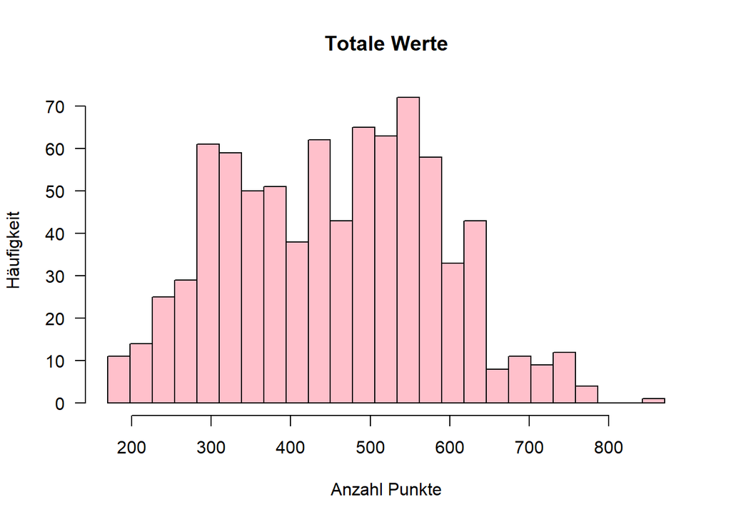

## Barplot Typ

Die folgenden zwei Diagramme zeigen die am meist vorkommenden ersten Typen und die am meist vorkommenden zweiten Typen.

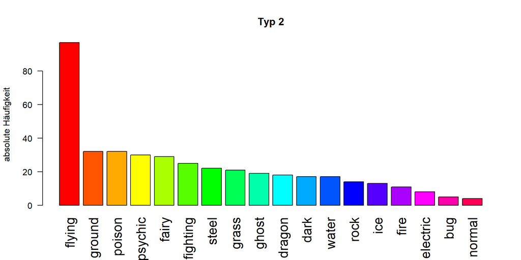

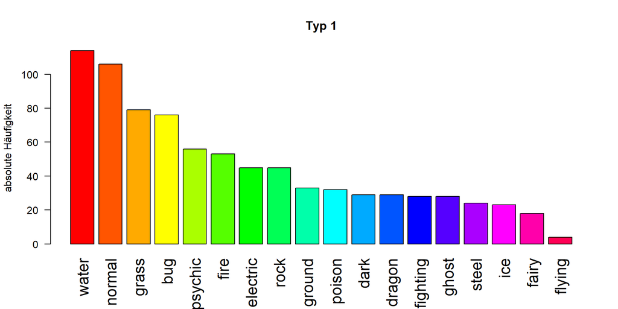

Wenn man nun die ersten vier Elemente der jeweiligen Balkendiagramme anschaut und sie in einem Mosaikplot plottet, kann man zusammenhänge zwischen den Typen erkennen:

## Mosaikplot meiste Typen 1 und 2

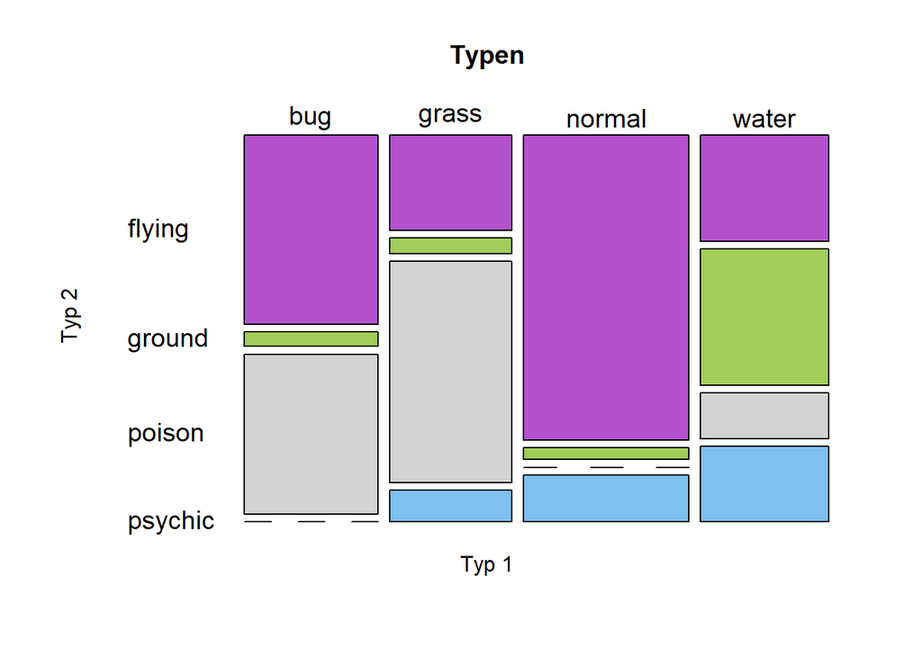

## Boxplot der Stärkepunkte pro Evolutionsstufe

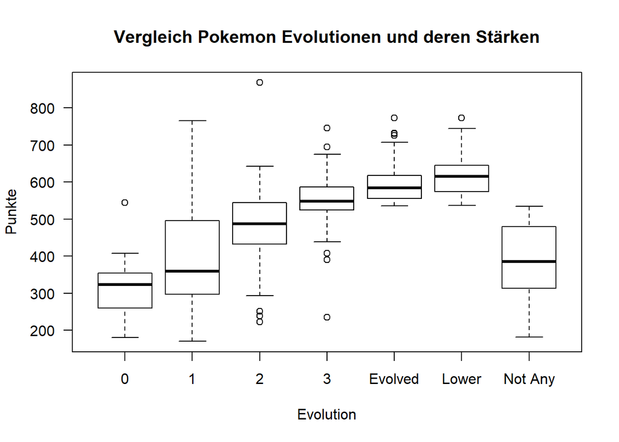

# Multivariate

## Mosaikplots der häufigsten Typen 1 und 2 und das entsprechende Wetter der Pokemon mit diesen Typen

I der folgenden Darstellung wird gezeigt, wie das Wetterattribut jedes Pokemons mit den Typen 1 und 2 korelliert. Wenn es zum Beispiel regnet wird bei den häufigsten Typen 1 nur “Water” und “Bug” vorkommen. Wenn “Partly Cloudy” das Wetterattribut der häufigsten Typen 1 ist, gibt es davon nur “Normal” Pokemon und wenn es “Sunny/Clear” ist, dann gibt es nur “Grass” Pokemon

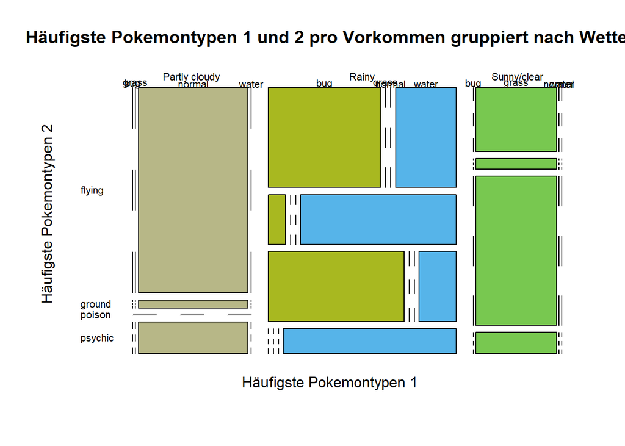

## Multivariate Boxplots

In diesem Diagramm wurden die häufigsten 4 Typen 1 auf ihre Stärkepunkte und Evolutionsstufen verglichen. Man sieht, dass einige der Typen zu einigen Evolutionsstufen gar keine Pokemon besitzen. Bei “Water”-Pokemon gibt es zum Beispiel auch nur jeweils 1 Pokemon bei Evolutionstufe 3 und Evolved. Mit einem Jitter wurden die Datenpunkte ersichtlich gemacht.

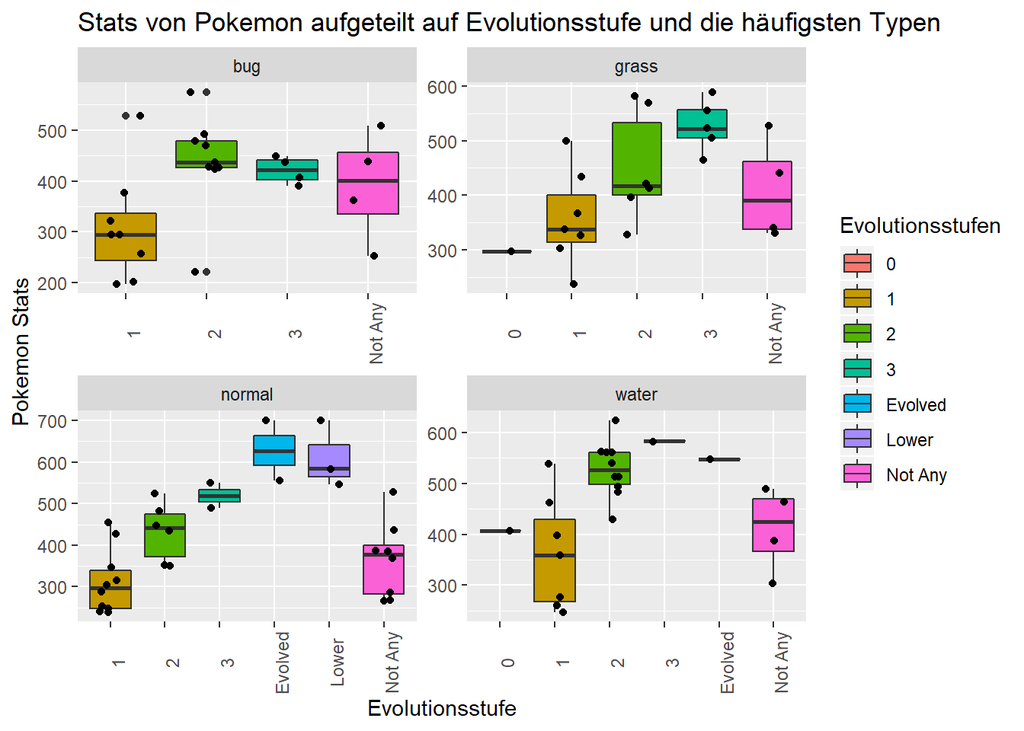

## Average stats total per pokemon type and their most common weather

Im nachfolgenden Diagramm sieht man alle Pokemontypen und deren mittleren Stärkepunkte. Die rote Gerade ist die durschnittliche Stärkepunktzahl aller Pokemon. Man sieht, dass “Drachen”- und “Stahl”-Pokemon durschnittlich am stärksten sind. Das Diagramm zeigt auch noch das Wetterattribut pro Pokemontyp, das für diesen Pokemontyp am häufigsten vorkommt. Bei Drachen wäre das “Windy”.

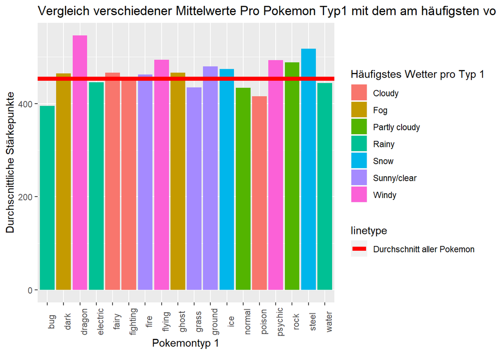

## Average stats total per weather type and their most common type 1

Das nachfolgende Diagramm kehrt das vorherige um. Es zeigt Die durschnittliche Stärkepunkteanzahl pro Wetter. In rot ist wieder der SChnitt aller Pokemon. Pro Wetter erkennt man farbig der Pokemontyp 1 der am häufigsten das entsprechende Wetterattribut besitzt. Bei “Windy” wäre dies beispielsweise “psychich”. Man sieht “Windy” hat den höchsten Schnitt, was mit den Drachenpokemon zu tun hat, die im vorherigen Diagramm den höchsten Schnitt haben und welche häufig das Wetterattribut “Windy” haben.

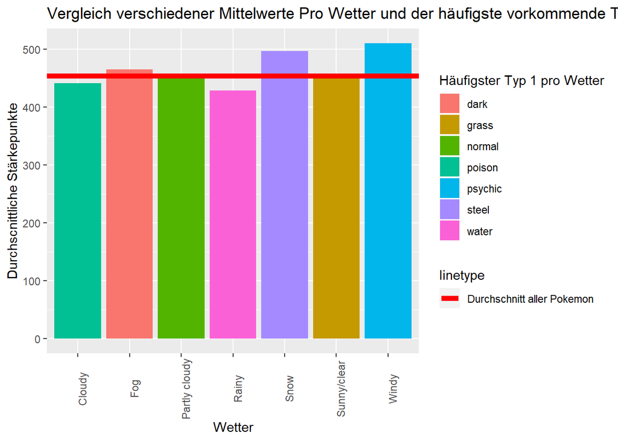